# 项目：探索TMDb电影数据集

## 目录

- 简介
- 数据整理
- 探索性数据分析
- 结论

## 简介

> 在这里我们将会使用一些数据可视化的方法来分析一下近几十年来一些有关电影的一些信息，我们使用的数据集来自“电影数据库”（TMDb，The Movie Database），当中涵盖了一万多条从上世纪60年代到2015年的电影的信息记录，记录了包括电影的受欢迎程度、制作成本、票房收入、演员、导演、电影时长、上映年份等信息。

> 我的思考将会从这几个关键的信息点出发：电影的受欢迎程度、电影的票房收入、以及电影的评分，基于此去尝试探讨这些特征与其他特征之间的联系。因此我提出了以下问题：

> 哪些类型的电影最受欢迎？

> 电影票房收入与哪些因素有关联？

> 人气较高的电影内容上都有什么特点?

> 哪些导演的作品评分最高？

```python
#导入必要的库
import pandas as pd
import numpy as np
import matplotlib.pyplot as plt
#设置magic关键字，让可视化图像在jupyter notebook上显示。
% matplotlib inline
```

## 数据整理

### 常规属性

```python
#读取数据
df=pd.read_csv("tmdb-movies.csv")
#查看数据集有哪些列名
df.head()
```

|  | id | imdb_id | popularity | budget | revenue | original_title | cast | homepage | director | tagline | ... | overview | runtime | genres | production_companies | release_date | vote_count | vote_average | release_year | budget_adj | revenue_adj |
| --- | --- | --- | --- | --- | --- | --- | --- | --- | --- | --- | --- | --- | --- | --- | --- | --- | --- | --- | --- | --- | --- |
| 0 | 135397 | tt0369610 | 32.985763 | 150000000 | 1513528810 | Jurassic World | Chris Pratt\|Bryce Dallas Howard\|Irrfan Khan\|Vi... | http://www.jurassicworld.com/ | Colin Trevorrow | The park is open. | ... | Twenty-two years after the events of Jurassic ... | 124 | Action\|Adventure\|Science Fiction\|Thriller | Universal Studios\|Amblin Entertainment\|Legenda... | 6/9/15 | 5562 | 6.5 | 2015 | 1.379999e+08 | 1.392446e+09 |
| 1 | 76341 | tt1392190 | 28.419936 | 150000000 | 378436354 | Mad Max: Fury Road | Tom Hardy\|Charlize Theron\|Hugh Keays-Byrne\|Nic... | http://www.madmaxmovie.com/ | George Miller | What a Lovely Day. | ... | An apocalyptic story set in the furthest reach... | 120 | Action\|Adventure\|Science Fiction\|Thriller | Village Roadshow Pictures\|Kennedy Miller Produ... | 5/13/15 | 6185 | 7.1 | 2015 | 1.379999e+08 | 3.481613e+08 |
| 2 | 262500 | tt2908446 | 13.112507 | 110000000 | 295238201 | Insurgent | Shailene Woodley\|Theo James\|Kate Winslet\|Ansel... | http://www.thedivergentseries.movie/#insurgent | Robert Schwentke | One Choice Can Destroy You | ... | Beatrice Prior must confront her inner demons ... | 119 | Adventure\|Science Fiction\|Thriller | Summit Entertainment\|Mandeville Films\|Red Wago... | 3/18/15 | 2480 | 6.3 | 2015 | 1.012000e+08 | 2.716190e+08 |
| 3 | 140607 | tt2488496 | 11.173104 | 200000000 | 2068178225 | Star Wars: The Force Awakens | Harrison Ford\|Mark Hamill\|Carrie Fisher\|Adam D... | http://www.starwars.com/films/star-wars-episod... | J.J. Abrams | Every generation has a story. | ... | Thirty years after defeating the Galactic Empi... | 136 | Action\|Adventure\|Science Fiction\|Fantasy | Lucasfilm\|Truenorth Productions\|Bad Robot | 12/15/15 | 5292 | 7.5 | 2015 | 1.839999e+08 | 1.902723e+09 |
| 4 | 168259 | tt2820852 | 9.335014 | 190000000 | 1506249360 | Furious 7 | Vin Diesel\|Paul Walker\|Jason Statham\|Michelle ... | http://www.furious7.com/ | James Wan | Vengeance Hits Home | ... | Deckard Shaw seeks revenge against Dominic Tor... | 137 | Action\|Crime\|Thriller | Universal Pictures\|Original Film\|Media Rights ... | 4/1/15 | 2947 | 7.3 | 2015 | 1.747999e+08 | 1.385749e+09 |

5 rows × 21 columns

> 这里先来详细了解以下各个列名的含义：

> id：电影的id

> imdb_id：电影在imdb数据库中的id

> popularity：电影的人气指数

> budget：电影的制作成本预算

> revenue：电影的票房收入

> original_title：电影的片名

> cast：电影主要演员

> homepage：电影主页

> director：电影导演

> tagline：电影的宣传语

> keywords：电影的卖点关键词

> overview：电影剧情简介

> runtime：电影片长

> genres：电影题材分类

> production_companies：电影制片商

> release_date：上映日期

> vote_count：评分次数

> vote_average：电影平均评分

> release_year：上映年份

> budget_adj：电影制作成本预算——调整

> revenue_adj：电影票房收入——调整

### 丢弃不需要的属性

> 根据我们问题的需要，丢弃一些这次分析不会用到的数据。

```python
#丢弃不需要的属性列
df.drop(columns=["id","imdb_id","homepage","tagline","overview","production_companies"],inplace=True)
#检查是否已经丢弃指定列
df.head()
```

|  | popularity | budget | revenue | original_title | cast | director | keywords | runtime | genres | release_date | vote_count | vote_average | release_year | budget_adj | revenue_adj |
| --- | --- | --- | --- | --- | --- | --- | --- | --- | --- | --- | --- | --- | --- | --- | --- |
| 0 | 32.985763 | 150000000 | 1513528810 | Jurassic World | Chris Pratt\|Bryce Dallas Howard\|Irrfan Khan\|Vi... | Colin Trevorrow | monster\|dna\|tyrannosaurus rex\|velociraptor\|island | 124 | Action\|Adventure\|Science Fiction\|Thriller | 6/9/15 | 5562 | 6.5 | 2015 | 1.379999e+08 | 1.392446e+09 |
| 1 | 28.419936 | 150000000 | 378436354 | Mad Max: Fury Road | Tom Hardy\|Charlize Theron\|Hugh Keays-Byrne\|Nic... | George Miller | future\|chase\|post-apocalyptic\|dystopia\|australia | 120 | Action\|Adventure\|Science Fiction\|Thriller | 5/13/15 | 6185 | 7.1 | 2015 | 1.379999e+08 | 3.481613e+08 |
| 2 | 13.112507 | 110000000 | 295238201 | Insurgent | Shailene Woodley\|Theo James\|Kate Winslet\|Ansel... | Robert Schwentke | based on novel\|revolution\|dystopia\|sequel\|dyst... | 119 | Adventure\|Science Fiction\|Thriller | 3/18/15 | 2480 | 6.3 | 2015 | 1.012000e+08 | 2.716190e+08 |
| 3 | 11.173104 | 200000000 | 2068178225 | Star Wars: The Force Awakens | Harrison Ford\|Mark Hamill\|Carrie Fisher\|Adam D... | J.J. Abrams | android\|spaceship\|jedi\|space opera\|3d | 136 | Action\|Adventure\|Science Fiction\|Fantasy | 12/15/15 | 5292 | 7.5 | 2015 | 1.839999e+08 | 1.902723e+09 |
| 4 | 9.335014 | 190000000 | 1506249360 | Furious 7 | Vin Diesel\|Paul Walker\|Jason Statham\|Michelle ... | James Wan | car race\|speed\|revenge\|suspense\|car | 137 | Action\|Crime\|Thriller | 4/1/15 | 2947 | 7.3 | 2015 | 1.747999e+08 | 1.385749e+09 |

### 检查与清理空缺值

```python
#检查是否存在空缺值
df.isnull().any()
```

```
popularity        False
budget            False
revenue           False
original_title    False
cast               True
director           True
keywords           True
runtime           False
genres             True
release_date      False
vote_count        False
vote_average      False
release_year      False
budget_adj        False
revenue_adj       False
dtype: bool
```

```python
#丢弃含空缺值的行
df.dropna(inplace=True)
#再次检查
df.isnull().any()
```

```
popularity        False
budget            False
revenue           False
original_title    False
cast              False
director          False
keywords          False
runtime           False
genres            False
release_date      False
vote_count        False
vote_average      False
release_year      False
budget_adj        False
revenue_adj       False
dtype: bool
```

### 检查重复行并去除

```python
#检查是否存在重复行
df.duplicated().any()
```

```
True
```

```python
#删除重复行
df.drop_duplicates(inplace=True)
#再次检查是否存在重复行
df.duplicated().any()
```

```
False
```

### 检查数据类型

```python
df.dtypes
```

```
popularity        float64
budget              int64
revenue             int64
original_title     object
cast               object
director           object
keywords           object
runtime             int64
genres             object
release_date       object
vote_count          int64
vote_average      float64
release_year        int64
budget_adj        float64
revenue_adj       float64
dtype: object
```

数据类型符合要求，无需进行数据类型转换

### 再次查看数据

```python
#检查数据目前的行数和列数
df.shape
```

```
(9306, 15)
```

```python
#利用描述性统计功能查看各个属性的数据分布
df.describe()
```

|  | popularity | budget | revenue | runtime | vote_count | vote_average | release_year | budget_adj | revenue_adj |
| --- | --- | --- | --- | --- | --- | --- | --- | --- | --- |
| count | 9306.000000 | 9.306000e+03 | 9.306000e+03 | 9306.000000 | 9306.000000 | 9306.000000 | 9306.000000 | 9.306000e+03 | 9.306000e+03 |
| mean | 0.707981 | 1.655383e+07 | 4.590105e+07 | 103.414249 | 247.627767 | 6.000355 | 2000.419514 | 1.991848e+07 | 5.929472e+07 |
| std | 1.063334 | 3.268917e+07 | 1.250529e+08 | 28.376247 | 616.013851 | 0.909980 | 13.068678 | 3.619063e+07 | 1.545408e+08 |
| min | 0.000188 | 0.000000e+00 | 0.000000e+00 | 0.000000 | 10.000000 | 1.500000 | 1960.000000 | 0.000000e+00 | 0.000000e+00 |
| 25% | 0.230966 | 0.000000e+00 | 0.000000e+00 | 91.000000 | 19.000000 | 5.400000 | 1993.000000 | 0.000000e+00 | 0.000000e+00 |
| 50% | 0.422673 | 3.500000e+05 | 0.000000e+00 | 100.000000 | 47.000000 | 6.100000 | 2005.000000 | 5.072968e+05 | 0.000000e+00 |
| 75% | 0.790917 | 2.000000e+07 | 3.378094e+07 | 113.000000 | 181.000000 | 6.600000 | 2011.000000 | 2.579055e+07 | 4.649618e+07 |
| max | 32.985763 | 4.250000e+08 | 2.781506e+09 | 900.000000 | 9767.000000 | 9.200000 | 2015.000000 | 4.250000e+08 | 2.827124e+09 |

注：以上数据看起来似乎仍然有点问题，比如在budget、revenue以及runtime中都存在一些数据内容不正常的现象，但由于探索性分析的第一部分暂时不需要用到这几个属性，因此这里先不用清理它们。

## 探索性数据分析

> 完成数据整理和清理之后，以下进行探索性数据分析。

### 研究问题1：哪种类型电影最受欢迎？

> 由于数据集中每部电影往往同时有多个分类，并且不同分类是用“|”隔开，因此需要用“|”将一行拆分为多行。以下代码实现这部份功能。

```python
#对genres一列的内容按照“|”将一行拆分为多行，并将拆分后的genres列保存到df_genres
df_genres=df["genres"].str.split("|",expand=True).stack().to_frame()
df_genres=df_genres.reset_index(level=1,drop=True).rename(columns={0:"genres"})
#将df_genres与删去genres列的df进行连接，结果另存为df_for_q1，专为问题1的分析而建立的数据框
df_for_q1=df.drop(columns=["genres"]).join(df_genres)
df_for_q1.head()
```

|  | popularity | budget | revenue | original_title | cast | director | keywords | runtime | release_date | vote_count | vote_average | release_year | budget_adj | revenue_adj | genres |
| --- | --- | --- | --- | --- | --- | --- | --- | --- | --- | --- | --- | --- | --- | --- | --- |
| 0 | 32.985763 | 150000000 | 1513528810 | Jurassic World | Chris Pratt\|Bryce Dallas Howard\|Irrfan Khan\|Vi... | Colin Trevorrow | monster\|dna\|tyrannosaurus rex\|velociraptor\|island | 124 | 6/9/15 | 5562 | 6.5 | 2015 | 1.379999e+08 | 1.392446e+09 | Action |
| 0 | 32.985763 | 150000000 | 1513528810 | Jurassic World | Chris Pratt\|Bryce Dallas Howard\|Irrfan Khan\|Vi... | Colin Trevorrow | monster\|dna\|tyrannosaurus rex\|velociraptor\|island | 124 | 6/9/15 | 5562 | 6.5 | 2015 | 1.379999e+08 | 1.392446e+09 | Adventure |
| 0 | 32.985763 | 150000000 | 1513528810 | Jurassic World | Chris Pratt\|Bryce Dallas Howard\|Irrfan Khan\|Vi... | Colin Trevorrow | monster\|dna\|tyrannosaurus rex\|velociraptor\|island | 124 | 6/9/15 | 5562 | 6.5 | 2015 | 1.379999e+08 | 1.392446e+09 | Science Fiction |
| 0 | 32.985763 | 150000000 | 1513528810 | Jurassic World | Chris Pratt\|Bryce Dallas Howard\|Irrfan Khan\|Vi... | Colin Trevorrow | monster\|dna\|tyrannosaurus rex\|velociraptor\|island | 124 | 6/9/15 | 5562 | 6.5 | 2015 | 1.379999e+08 | 1.392446e+09 | Thriller |
| 1 | 28.419936 | 150000000 | 378436354 | Mad Max: Fury Road | Tom Hardy\|Charlize Theron\|Hugh Keays-Byrne\|Nic... | George Miller | future\|chase\|post-apocalyptic\|dystopia\|australia | 120 | 5/13/15 | 6185 | 7.1 | 2015 | 1.379999e+08 | 3.481613e+08 | Action |

> 各种电影分类的描述性统计：

```python
#查看不同分类的受欢迎程度的描述性统计
df_for_q1.groupby(["genres"])['popularity'].describe().sort_values(by=["mean"],ascending=False)
```

| genres | count | mean | std | min | 25% | 50% | 75% | max |
| --- | --- | --- | --- | --- | --- | --- | --- | --- |
| Adventure | 1326.0 | 1.240474 | 2.048745 | 0.010213 | 0.318738 | 0.622324 | 1.393312 | 32.985763 |
| Science Fiction | 1087.0 | 1.094263 | 2.111286 | 0.002648 | 0.260155 | 0.505750 | 1.104195 | 32.985763 |
| Fantasy | 807.0 | 1.078141 | 1.360983 | 0.013814 | 0.317014 | 0.582583 | 1.274699 | 11.173104 |
| Animation | 536.0 | 1.004593 | 1.092591 | 0.005502 | 0.346611 | 0.614148 | 1.268712 | 8.691294 |
| Action | 2122.0 | 0.999256 | 1.608336 | 0.002648 | 0.283014 | 0.517187 | 1.103412 | 32.985763 |
| Family | 1015.0 | 0.879521 | 1.043856 | 0.002165 | 0.271300 | 0.523153 | 1.089667 | 8.691294 |
| Thriller | 2582.0 | 0.789803 | 1.293965 | 0.002381 | 0.276353 | 0.477038 | 0.885716 | 32.985763 |
| War | 242.0 | 0.776097 | 0.998477 | 0.010335 | 0.250117 | 0.458286 | 0.928680 | 8.110711 |
| Crime | 1240.0 | 0.775314 | 0.918201 | 0.001372 | 0.289577 | 0.497618 | 0.904805 | 9.335014 |
| Mystery | 729.0 | 0.730575 | 0.903230 | 0.000188 | 0.250989 | 0.469314 | 0.873688 | 9.363643 |
| Comedy | 3270.0 | 0.645439 | 0.714502 | 0.000188 | 0.235298 | 0.436606 | 0.785648 | 8.691294 |
| Romance | 1504.0 | 0.634341 | 0.645342 | 0.003311 | 0.245033 | 0.428002 | 0.774435 | 6.715966 |
| Drama | 4201.0 | 0.631526 | 0.838596 | 0.000188 | 0.244298 | 0.415262 | 0.715437 | 24.949134 |
| History | 304.0 | 0.607371 | 0.693876 | 0.001372 | 0.247752 | 0.452990 | 0.748199 | 8.110711 |
| Western | 156.0 | 0.604739 | 0.998892 | 0.020760 | 0.233818 | 0.333603 | 0.620163 | 9.110700 |
| Music | 352.0 | 0.530365 | 0.606939 | 0.003238 | 0.194409 | 0.350031 | 0.618965 | 4.780419 |
| Horror | 1418.0 | 0.494711 | 0.562836 | 0.001423 | 0.188999 | 0.333344 | 0.581897 | 8.411577 |
| TV Movie | 131.0 | 0.271671 | 0.192809 | 0.012059 | 0.121910 | 0.235116 | 0.361935 | 1.223392 |
| Foreign | 126.0 | 0.209199 | 0.147931 | 0.002514 | 0.106546 | 0.170183 | 0.273560 | 0.741302 |
| Documentary | 375.0 | 0.201685 | 0.172022 | 0.001117 | 0.077723 | 0.161552 | 0.273292 | 1.005772 |

> 各种电影分类的平均受欢迎程度可视化:

```
Text(0.5,1,'Average popularity of different movie types')
```

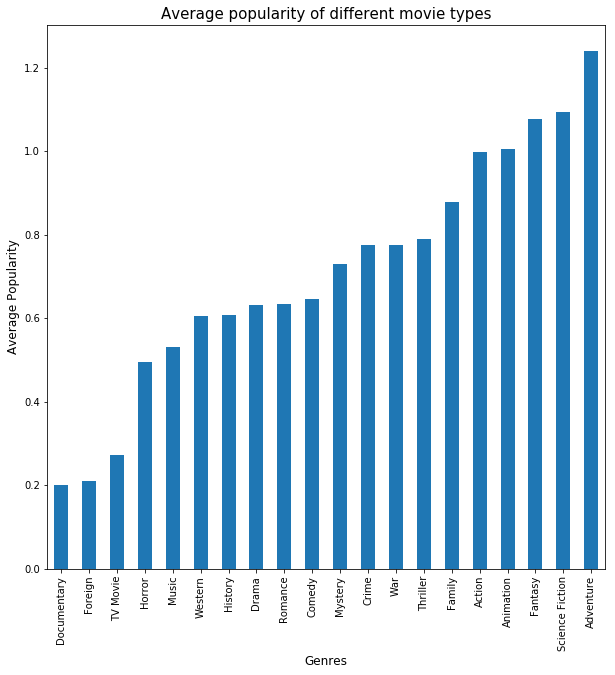

```python
#对不同分类的平均受欢迎程度进行可视化展示
df_for_q1.groupby(['genres'])['popularity'].mean().to_frame().sort_values(by='popularity').plot(kind="bar",figsize=(10,10),legend=False);
plt.ylabel("Average Popularity", fontsize=12)
plt.xlabel("Genres",fontsize=12)
plt.title("Average popularity of different movie types",fontsize=15)
```

### 研究问题2：电影票房收入与哪些因素有关联？

> 首先需要对数据重新检视并稍加整理以便分析

```python
#再次检查原先已经整理好的数据
df.describe()
```

|  | popularity | budget | revenue | runtime | vote_count | vote_average | release_year | budget_adj | revenue_adj |
| --- | --- | --- | --- | --- | --- | --- | --- | --- | --- |
| count | 9306.000000 | 9.306000e+03 | 9.306000e+03 | 9306.000000 | 9306.000000 | 9306.000000 | 9306.000000 | 9.306000e+03 | 9.306000e+03 |
| mean | 0.707981 | 1.655383e+07 | 4.590105e+07 | 103.414249 | 247.627767 | 6.000355 | 2000.419514 | 1.991848e+07 | 5.929472e+07 |
| std | 1.063334 | 3.268917e+07 | 1.250529e+08 | 28.376247 | 616.013851 | 0.909980 | 13.068678 | 3.619063e+07 | 1.545408e+08 |
| min | 0.000188 | 0.000000e+00 | 0.000000e+00 | 0.000000 | 10.000000 | 1.500000 | 1960.000000 | 0.000000e+00 | 0.000000e+00 |
| 25% | 0.230966 | 0.000000e+00 | 0.000000e+00 | 91.000000 | 19.000000 | 5.400000 | 1993.000000 | 0.000000e+00 | 0.000000e+00 |
| 50% | 0.422673 | 3.500000e+05 | 0.000000e+00 | 100.000000 | 47.000000 | 6.100000 | 2005.000000 | 5.072968e+05 | 0.000000e+00 |
| 75% | 0.790917 | 2.000000e+07 | 3.378094e+07 | 113.000000 | 181.000000 | 6.600000 | 2011.000000 | 2.579055e+07 | 4.649618e+07 |
| max | 32.985763 | 4.250000e+08 | 2.781506e+09 | 900.000000 | 9767.000000 | 9.200000 | 2015.000000 | 4.250000e+08 | 2.827124e+09 |

> 以上数据看起来有些问题，比如在电影制作成本方面，至少有25%的电影制作成本都为零，同时还存在电影时长为0分钟的情况，在这里去探讨造成这些不正常数据的背后原因是困难的，并且这也不是这次分析的重点。因此需要对这些数据筛选出正常的部分进行分析。 通过查阅相关资料可知，历史上确实存在过一些成本低至几万甚至几千美元的电影，同时也存在过一些时长仅有几十分钟的电影。因此这里大致可以筛选出制作成本大于5000，同时电影时长大于50分钟的数据。

```python
#为了避免对分析结果产生影响，选择将那些制作成本和电影时长都为0的数据去除，结果存为df_for_q2，为分析问题2而筛选的数据集
df_for_q2=df.query("budget>5000").query("runtime>50")
#再次检查
df_for_q2.describe()
```

|  | popularity | budget | revenue | runtime | vote_count | vote_average | release_year | budget_adj | revenue_adj |
| --- | --- | --- | --- | --- | --- | --- | --- | --- | --- |
| count | 4764.000000 | 4.764000e+03 | 4.764000e+03 | 4764.000000 | 4764.000000 | 4764.000000 | 4764.000000 | 4.764000e+03 | 4.764000e+03 |
| mean | 1.043021 | 3.232075e+07 | 8.604291e+07 | 108.103694 | 437.143367 | 6.066709 | 2000.879513 | 3.889114e+07 | 1.096769e+08 |
| std | 1.368691 | 3.971613e+07 | 1.643502e+08 | 22.003525 | 813.684009 | 0.865219 | 11.853281 | 4.266412e+07 | 2.018314e+08 |
| min | 0.001117 | 7.000000e+03 | 0.000000e+00 | 55.000000 | 10.000000 | 1.500000 | 1960.000000 | 7.597954e+03 | 0.000000e+00 |
| 25% | 0.378649 | 7.000000e+06 | 3.140175e+05 | 94.000000 | 42.000000 | 5.500000 | 1995.000000 | 9.478370e+06 | 3.555957e+05 |
| 50% | 0.664263 | 1.900000e+07 | 2.602997e+07 | 104.000000 | 140.000000 | 6.100000 | 2004.000000 | 2.489221e+07 | 3.464654e+07 |
| 75% | 1.210754 | 4.000000e+07 | 9.757144e+07 | 118.000000 | 440.000000 | 6.700000 | 2010.000000 | 5.282824e+07 | 1.252244e+08 |
| max | 32.985763 | 4.250000e+08 | 2.781506e+09 | 540.000000 | 9767.000000 | 8.400000 | 2015.000000 | 4.250000e+08 | 2.827124e+09 |

> 利用散点图探索电影票房收入与各个因素的关联性

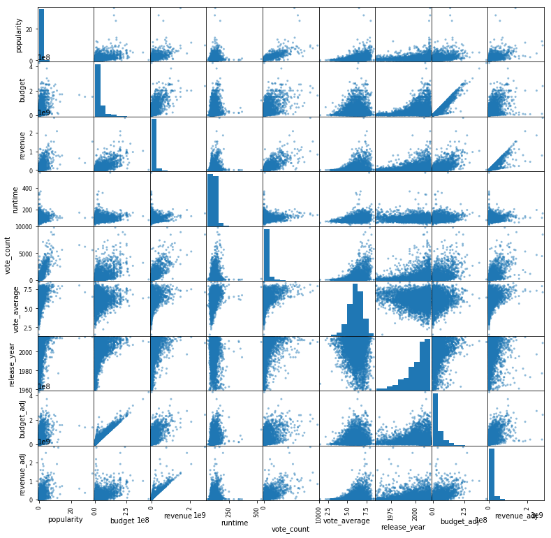

```python
#利用散点图探索不同属性之间的相关性
pd.plotting.scatter_matrix(df_for_q2,figsize=(13,13));
```

### 研究问题3：人气较高的电影内容上都有什么特点？

> 这里我们以人气指数排前50%的电影为高人气电影，将其筛选出来，以关键词内容来分析其题材和特征。

```python
#通过描述统计查看中位数
df["popularity"].describe()
```

```
count    9306.000000
mean        0.707981
std         1.063334
min         0.000188
25%         0.230966
50%         0.422673
75%         0.790917
max        32.985763
Name: popularity, dtype: float64
```

```python
#筛选出受欢迎程度排前50%的数据，存为df_for_q3
df_for_q3=df.query("popularity>0.423")
```

> keywords该列同样存在多个词用“|”分隔的问题，但这里不需要再做分行的处理，而是定义一个函数来计算不同关键词的出现次数。该函数要实现的功能是：**对数据框中的关键词进行分割操作，并将每个分割后的关键词与其对应的出现次数保存到一个pandas序列中，返回该序列。**

```python
#定义一个函数来实现该功能
def keywords_count(series):
    keyword_series=pd.Series()
    for i in series.str.split("|"):
        for j in i:
            if j in keyword_series:
                keyword_series[j]+=1
            else:
                keyword_series[j]=1
    return keyword_series
```

> 接下来利用该函数来计算数据集中各个关键词的出现次数

```python
#运用已定义的函数获得各个关键词及其出现次数的数据序列
keyword_collection=keywords_count(df_for_q3['keywords'])
#查看返回的序列中有多少元素
keyword_collection.shape
```

```
(5515,)
```

> 目前该关键词列表内元素过多，这不利于作图进行可视化展示，考虑将其按照大小排序，并选出排前40位出现次数最多的关键词来进行可视化。

```python
#按出现次数筛选出排前40的关键词
keyword_collection_top40=keyword_collection.sort_values(ascending=False)[0:40]
```

> 利用可视化展示40个关键词

```
Text(0.5,1,'Which Type Of Content Are Most Popular?')
```

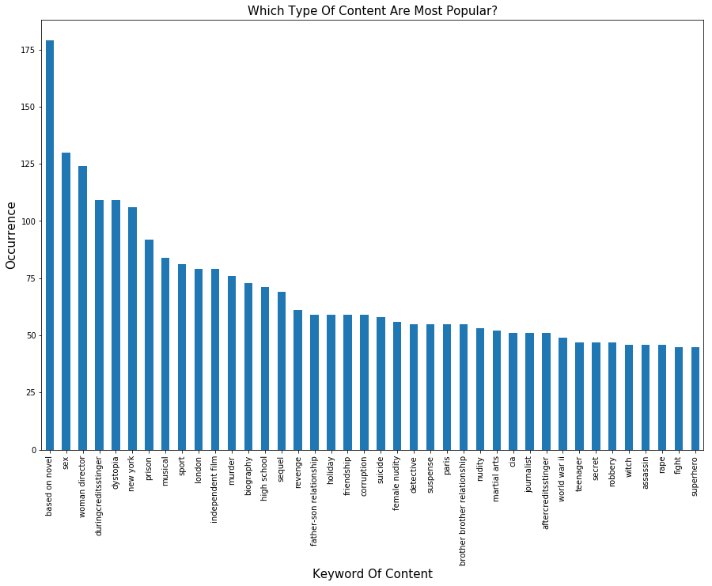

```python
#进行可视化展示
keyword_collection_top40.to_frame().plot(kind='bar',figsize=(15,10),legend=False);
plt.xlabel("Keyword Of Content",fontsize=15)
plt.ylabel("Occurrence",fontsize=15)
plt.title("Which Type Of Content Are Most Popular?",fontsize=15)
```

### 研究问题4：哪些导演的作品评分最高？

> 考虑到director这一列同样可能存在一行有多个值、并用“|”分隔的情况，因此按照前述的方法将其一行分为多行。

```python
df_director=df["director"].str.split("|",expand=True).stack().to_frame()
df_director=df_director.reset_index(level=1,drop=True).rename(columns={0:"director"})
df_for_q4=df.drop(columns=["director"]).join(df_director)
```

> 由于数据集中导演的数量非常多，这里挑选平均评分最高的10名来进行可视化展示：

```
Text(0.5,1,'Directors With The Highest Average Vote')
```

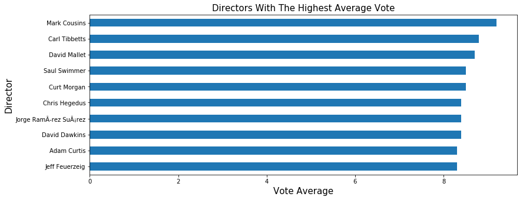

```python
df_for_q4.groupby(['director'])['vote_average'].mean().sort_values(ascending=False).head(10).to_frame().plot(kind='barh',figsize=(13,5),legend=False);
plt.gca().invert_yaxis()
plt.xlabel("Vote Average",fontsize=15)
plt.ylabel("Director",fontsize=15)
plt.title("Directors With The Highest Average Vote",fontsize=15)
```

## 结论

> 最后根据我们已经做过的调查，来尝试回答最初提出的四个问题：

> 电影票房收入与哪些因素存在关联

> 如可视化结果那样，我们可以看到电影票房收入与电影的受欢迎程度、制作成本预算、评分次数等有关，其中与评分次数有关的原因可能是因为票房收入较高的电影其人气较高，因此观看并参与评分的人数较多。另外从散点图上来看，并未发现电影票房收入与电影评分高低有密切关联。

> 人气较高的电影的特征

> 在人气较高的电影中，关键词“基于小说”的出现次数最多，其次依次是性、女导演、反乌托邦、纽约、监狱、音乐、体育、伦敦、独立电影、谋杀等。这可以显示出观众比较感兴趣的故事题材内容。

> **需要注意的是，以上结果仅仅是通过可视化得出的初步结论，因此该结论只是暂时的。这些结论尚未经过统计验证，未来需要通过相关统计学方法对其进一步验证。**